# Function of the Week:

Hoda Mohammed

2023-02-15

# `fct_relevel`

> In this document, I will introduce the **fct_relevel** function and show what it’s used for.

> **fct_relevel** is part of the **forcats** R package.

> I will be using `icu_Hoda_edited` dataset adapted from 513 BSTA class.

### I am interested in “race” in this dataframe.

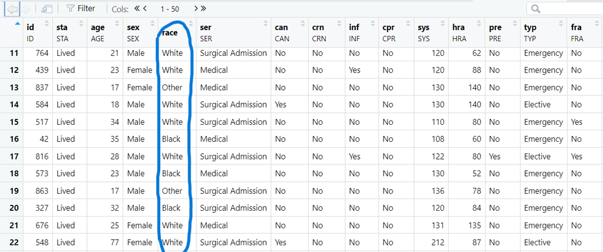

```r
tabyl (icu_Hoda_edited$race)
```

```
##  icu_Hoda_edited$race   n percent
##                 Black  15   0.075
##                 Other  10   0.050
##                 White 175   0.875
```

```r
class(icu_Hoda_edited$race)
```

```
## [1] "character"
```

> I factorize it then check for its levels.

```r
icu_Hoda_edited <-icu_Hoda_edited%>% mutate(race= factor(race))
class(icu_Hoda_edited$race)
```

```
## [1] "factor"
```

```r
levels(icu_Hoda_edited$race)
```

```
## [1] "Black" "Other" "White"
```

### The **default** order for levels with factor() is **ALPHABETICAL**.

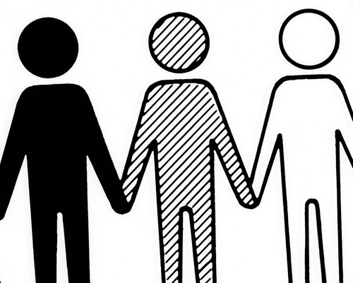

## What is fct_relevel used for?

> The function simply is used to **reorder factor levels by hand** when we want to **specify the reference level**.

> (e.g. when plotting, or when performing a regression analysis)

> If we want to make comparisons relative to “White” race, we need to **move it to the front** by **using fct_relevel()**.

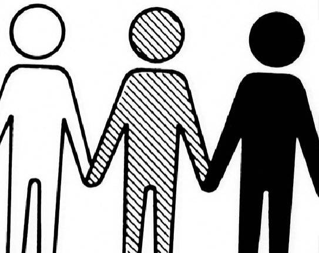

```r
icu_Hoda_edited <- icu_Hoda_edited%>%
  mutate(race = race %>%
           fct_relevel("White"))

levels(icu_Hoda_edited$race)
```

```
## [1] "White" "Black" "Other"
```

### “White” has moved to to be the first level (reference).

### The rest of the other levels remain ordered **alphabetically**.

### If we desire to move “Other” to be the second level, we add it to the argument.

```r
icu_Hoda_edited <- icu_Hoda_edited%>%
  mutate(race = race %>%
           fct_relevel("White","Other"))

levels(icu_Hoda_edited$race)
```

```
## [1] "White" "Other" "Black"
```

### Similar functions:

### levels()

> race_factor <- factor(race_character,**levels** = c(“White”, “Other”, “Black”))
- Useful when creating a factor.
- May not be helpful if we have a lot of levels because we will need to write them all down - long code!

### relevel()

> race_factor<-**relevel**(race_factor, ref=“White”)
- Useful for specifying only the reference (1st level)

## Is it helpful?

> YES! **fct_relevel** is useful if we want to **reorder the levels** in a factor to **specify the reference level**.

> Helps us “pull” a level (or more) to the *front* relative to all other levels. The rest of the levels remain unchanged and follow according to their alphabetical order.

Source: R for Health Data Science Ewen Harrison and Riinu Pius 2021-01-15 https://argoshare.is.ed.ac.uk/healthyr_book/chap08-h2-fct-relevel.html